## BASIS FOR ASSESSMENT

### Assessment Details

SoG Pacific Herring are assessed using a spatially integrated statistical catch at age herring (SISCAH) modelling framework within a management strategy evaluation (MSE) process (DFO 2023a), fitted using spawn survey indices, fishery age composition data, and commercial catches.

For SoG Herring, the SISCAH operating model includes: density dependent mortality (DDM), integrated surface and dive survey data in the index, commercial fishery timing, and a likelihood function with correlated age-compositions.

A weighted operating model is used for the management procedure evaluation, whereby the weighted model represents a range of productivity characterized by the stock recruitment steepness ($h$) and the lower limit on natural mortality ($M_b$). This approach better represents the uncertainty in stock productivity rather than using a single estimated value of $h$.

Details of operating model development are described in Appendix A.

Management procedures (MPs) were simulation tested using a 15-year projection period (2024-2038); only MPs that meet the established conservation objective (DFO 2023b) are presented.

#### Year Assessment Approach was Approved

2023 S. D. N. Johnson and Rossi (2024).

#### Assessment Type

Full Assessment and MSE process.

#### Most Recent Assessment Date

1. Last Full Assessment: 2024 (this document).

#### Assessment Approach

1. Broad category: Single stock operating model ensemble (full MSE process).
2. Specific category: Index-based, statistical catch-at-age model, density dependent time varying natural mortality, and Beverton-Holt stock-recruitment relationship.

This 2024 SISCAH modelling framework (S. D. N. Johnson and Rossi 2024) includes stock status and MP for SoG Herring.

### Stock Structure Assumption

Stock overview information: SoG Herring is one of five major stocks managed in British Columbia. Data collection and assessment focuses on the core spawn timing associated with the main migratory stock. Adult herring are reported in various areas of the Salish Sea during the summer months indicating some level of non-migratory life history, with the largest component of the stock migrating to the west coast to share summer/ fall feeding grounds with the West Coast Vancouver Island herring.

### Reference Points

A suite of biological and fishery reference points are included for SoG Herring. These are: 1. Fractions of unfished biomass, ${SB_0}$ 1. ${MSY}$ 1. Fractions of $U_{MSY}$

In 2018, a biological limit reference point (LRP) was defined for Pacific Herring major stocks as $0.3SB_0$ in 2018, where ${SB_0}$ is the long-term average estimated unfished spawning biomass (Kronlund et al. 2017).

Candidate USRs were first introduced in Cleary et al. (2019) and a formal analysis of USR options was undertaken in 2022 with results presented in DFO (2023b). In 2023, DFO Resource Management selected and implemented a provisional USR of $\overline{\mathit{SB}}$, implemented as a performance metric within 2022/23 IFMP process.

### Fishery management objectives

A core set of fisheries management objectives (DFO 2020) were introduced to the Pacific Herring MSE process in 2019. The first of these is a conservation objective, which is centered on the LRP.

1. Maintain spawning biomass at or above the LRP with at least 75% probability over three Pacific Herring generations (i.e., avoid a biomass limit; $P(\mathit{SB}_t \geq 0.3 \mathit{SB}_0) \geq 0.75$),
2. Maintain spawning biomass at or above the USR with at least 50% probability over three Pacific Herring generations (i.e., achieve a target biomass; $P(\mathit{SB}_t \geq \mathit{SB}_{targ}) \geq 0.50$),
3. Maintain average annual variability (AAV) in catch below 25% over three Pacific Herring generations (i.e., minimize catch variability; $\text{AAV} < 0.25$), and
4. Maximize average annual catch over three Pacific Herring generations (i.e., maximize average catch).

Operating model development began for Herring MSE in 2015, however a fully specified set of objectives has not yet been developed for each SAR. DFO will continue to collaborate with coastal First Nations to develop area-specific objectives FSC fisheries as well as SOK fisheries (where applicable). In addition, DFO will continue to engage with the herring industry and government and non-government organizations to describe broader objectives related to conservation, economics, and access.

### Stock Status

SoG stock status is defined from the operating model (Appendix A).

### Data

There are three types of input data used for the Pacific Herring stock assessment: catch data, biological data, and a fishery independent survey index.

Note that we refer to ‘year’ instead of ‘herring season’ in this report; therefore 2024 refers to the 2023/2024 Pacific Herring season.

## ASSESSMENT

[figure not shown]

### Ecosystem and Climate Change Considerations

Density dependence, where increased mortality is associated with smaller biomass models ecosystem effects such as the increased percentage of natural mortality in the event of lower bio-masses due to a constant predatory removal.

## BYCATCH

Some fisheries and aquaculture activities in BC cause incidental mortality to Pacific Herring. Similar to SOK harvest as well as FSC and recreational catch, incidental mortality is currently only indirectly accounted for in Pacific Herring stock assessment by estimating annual rates of natural mortality, and is considered minor relative to commercial harvest.

## LIST OF MEETING PARTICIPANTS

# A APPENDIX A

This appendix summarises closed loop simulations evaluating candidate management procedures for the Strait of Georgia (SOG) herring fishery. SOG herring is the first BC herring fishery to use the new herring operating model framework, named the Spatially Integrated Statistical Catch-at-Age Herring Operating Model (SISCAH-OM). Although there are several differences between SISCAH and the previous herring assessment and operating models, the main difference in SISCAH-OM is the ability to model density dependent mortality (DDM), where natural mortality is higher when biomass is lower (S. D. N. Johnson and Rossi 2024).

All candidate MPs are tested against a suite of five SISCAH operating models, which incorporate uncertainty in future productivity at both low and high stock sizes. We first summarise the simulation approach, and then present results weighted over the five operating models, with some brief discussion of the management implications.

# B Simulation approach

## B.1 Operating models

This creates a cross design (Table B.1) with a central OM (called OM1, $M_b=0.562$ and $h = 0.7$) which we gave a weight of 0.34. The remaining operating models are weighted equally  
with a weight of 0.165. These weights are used to calculated a weighted average for the MP metrics.

For all operating models, we report leading OM parameters, current biomass and stock status, and $MSY$ based reference points (Table B.1).

Table B.1: SISCAH-OM life-history and management parameter values for stock-recruit steepness ($h$), asymptotic lower limit on depensatory $M$ ($M_b$, /yr), unfished biomass ($SB_0$, kt), unfished recruitment ($R_0$, 1e6), unfished mortality ($M_0$, /yr), mortality depensation rate ($m_1$), time-averaged mortality ($\overline{M}$, /yr), surface survey design catchability ($q_s$), spawning biomass in 2023 ($SB_{2023}/SB_0$), stock status ($P(SB_{2023} > 0.3 SB_0)$), spawning biomass at maximum sustainable yield ($SB_{MSY}$, kt), harvest rate targeting maximum sustainable yield ($U_{MSY}$), maximum sustainable yield ($MSY$), upper stock reference ($USR$, kt), harvest rate targeting the upper stock reference ($U_{USR}$), equilibrium yield at the upper stock reference ($Y_{USR}$), harvest rate associated with negative production and higher risk of extirpation ($U_{Crash}$). Uncertainty is shown as the 95% credible interval where estimates could be drawn from posterior samples (indicated by two parenthetical values), or half the interquartile range where estimates were drawn from 200 year simulations (one parenthetical value).

|  | OM 1 | OM 2 | OM 3 | OM 4 | OM 5 | Ensemble |
| --- | --- | --- | --- | --- | --- | --- |
| $h$ | 0.70 | 0.65 | 0.75 | 0.70 | 0.70 | 0.70 |
| $M_b$ | 0.562 | 0.562 | 0.562 | 0.532 | 0.584 | 0.560 |
| $M_0$ | 0.58 (0.56, 0.65) | 0.58 (0.56, 0.66) | 0.58 (0.56, 0.64) | 0.57 (0.53, 0.66) | 0.6 (0.58, 0.66) | 0.58 |
| $m_1$ | 4.52 (2.43, 7.42) | 4.58 (2.33, 7.85) | 4.52 (2.52, 7.77) | 3.92 (2.03, 6.78) | 4.84 (2.64, 8.01) | 4.48 |
| $\overline{M}$ | 0.6 (0.57, 0.63) | 0.6 (0.57, 0.64) | 0.6 (0.57, 0.64) | 0.59 (0.56, 0.63) | 0.61 (0.58, 0.64) | 0.6 |
| $q_s$ | 0.7 (0.57, 0.86) | 0.7 (0.56, 0.86) | 0.71 (0.57, 0.85) | 0.72 (0.58, 0.88) | 0.69 (0.55, 0.84) | 0.7 |
| $q_d$ | 1 (1, 1) | 1 (1, 1) | 1 (1, 1) | 1 (1, 1) | 1 (1, 1) | 0.99 |
| $q_{blend}$ | 0.86 (0.79, 0.93) | 0.86 (0.79, 0.93) | 0.86 (0.8, 0.93) | 0.87 (0.8, 0.94) | 0.85 (0.78, 0.92) | 0.86 |
| $R_0$ | 2145.64 (1671.28, 2753.85) | 2150.36 (1677.67, 2750.14) | 2120.51 (1684.48, 2658.85) | 2001.35 (1579.99, 2519.71) | 2263.97 (1777.08, 2874.07) | 2137.99 |
| $B_0$ | 88.58 (36.93) | 88.25 (40.18) | 92.51 (37.14) | 91.54 (42.55) | 92.05 (36.67) | 90.23 |
| $B_{2023}$ | 84.54 (55.46, 122.08) | 84.35 (56.53, 122.32) | 84.64 (54.64, 121.94) | 84.56 (56.45, 119.75) | 83.36 (54.37, 118.02) | 84.33 |
| $B_{2023}/B_0$ | 0.95 (0.63, 1.38) | 0.96 (0.64, 1.39) | 0.91 (0.59, 1.32) | 0.92 (0.62, 1.31) | 0.91 (0.59, 1.28) | 0.93 |
| $P(B_{2023} > 0.3 B_0)$ | 0.99 | 0.99 | 0.99 | 0.99 | 0.99 | 0.99 |
| $B_{MSY}$ | 37.81 (13.27) | 44.71 (17.15) | 34.48 (12.89) | 43.68 (18.23) | 36.35 (15.32) | 39.13 |
| $U_{MSY}$ | 0.185 (0.077) | 0.122 (0.066) | 0.261 (0.079) | 0.145 (0.063) | 0.229 (0.072) | 0.19 |
| $MSY$ | 8.876 (6.578) | 6.480 (5.560) | 12.537 (8.005) | 7.626 (6.113) | 11.329 (7.497) | 9.28 |
| $U_{USR}$ | 0.078 (0.102) | 0.060 (0.084) | 0.099 (0.123) | 0.077 (0.098) | 0.096 (0.117) | 0.08 |
| $USR$ | 67.18 (60.08, 75.49) | 67.37 (60.38, 76.1) | 67.46 (60.7, 75.8) | 66.29 (59.15, 75.4) | 68.4 (61.21, 77.83) | 67.31 |
| $Y_{USR}$ | 5.774 (7.848) | 4.390 (6.444) | 7.511 (10.040) | 5.627 (7.455) | 7.402 (9.393) | 6.08 |
| $U_{Crash}$ | 0.279 (0.097) | 0.166 (0.115) | 0.419 (0.095) | 0.261 (0.074) | 0.316 (0.112) | 0.29 |

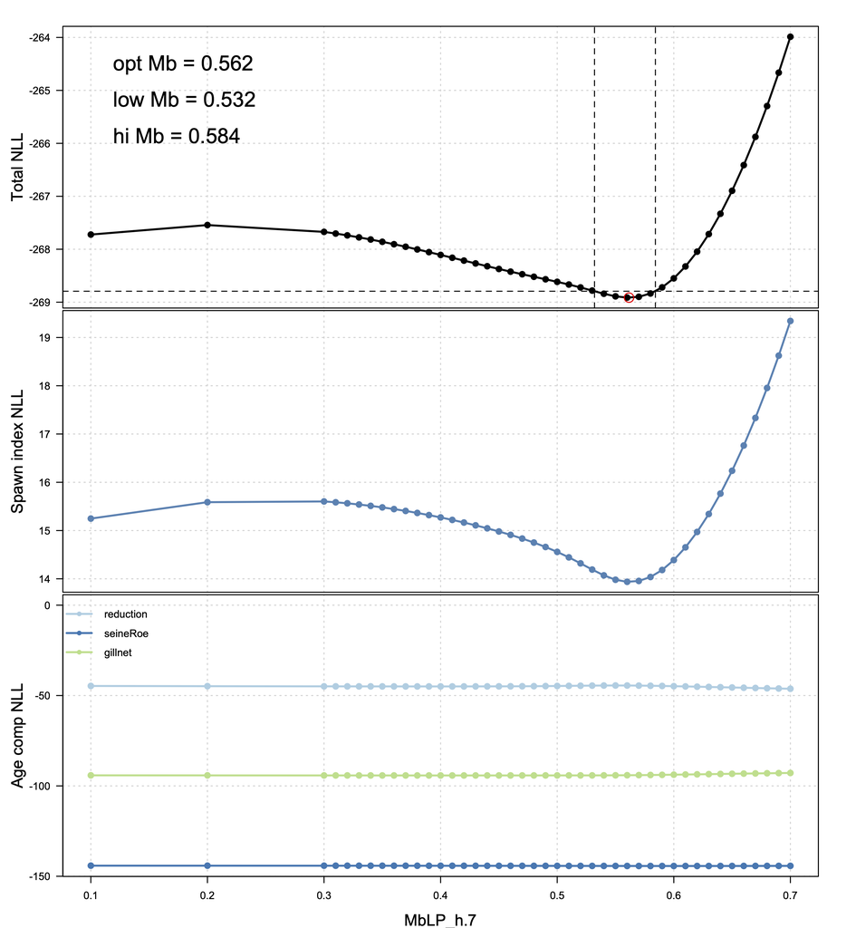

Figure B.1: Fishery monitoring data likelihood function profiles relative to a range of natural mortality asymptotic lower limit ($M_b$) parameter values. The red point shows the most likely value, while the two vertical dashed lines show two values with equal likelihood chosen to bound the central OM1. All SISCAH model fits here have a steepness value of $h = 0.7$

## B.2 Management Procedures

Management procedures are a combination of data, biomass estimation method (EM), and a harvest control rule (HCR).

TACs are derived from EM estimates via the harvest control rule. For SOG herring, we use a “hockey-stick” shaped function with control points at 30% and 60% of unfished biomass, also known as biomass depletion. When biomass depletion is estimated to be below the lower control point, the rule sets the harvest rate to zero; between the control points the harvest rate is a ramp from zero to the maximum harvest rate. Above the upper control point, the rule sets harvest rates to the maximum target harvest rate, called $maxTHR$. We show results for maximum target harvest rates of 6% and 14% (Figure B.2).

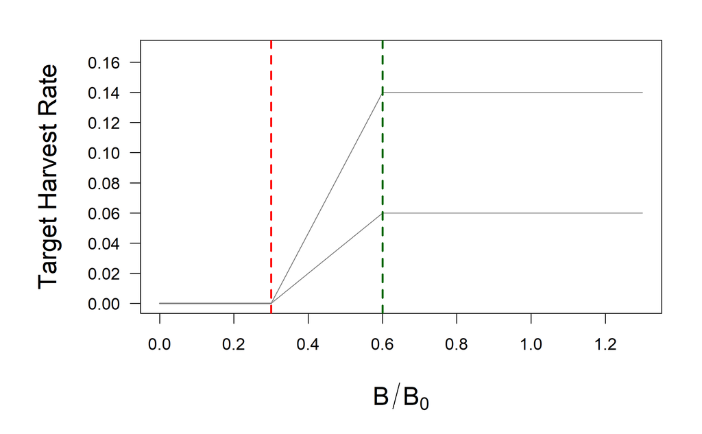

Figure B.2: Two harvest control rules tested for candidate SOG herring MPs, showing maximum target harvest rates $maxTHR$ of 6% and 14%.

## B.3 Performance metrics

First, MPs are quantitatively evaluated against the conservation objective (the primary management objective):

1. $P(B_t > 0.3 B_0) \geq 0.75$, or **avoid the limit reference point (LRP) with high probability over three herring generations.**

and next against secondary biomass objective:

2. $P(B_t > USR) \geq 0.5$, or **provisional upper stock reference (USR) with neutral probability**.

Objective 1, also known as the conservation objective, must be passed by all Herring management procedures. Objective 2 is a target biomass objective that includes the recently described provisional $USR$.

To help fishery managers understand trade-offs among biomass and yield, additional quantitative performance metrics are estimated. These metrics do not have a minimum or target value like objectives, but give greater detail on biomass and yield outcomes of each MP over the 15 year simulation.

1. $P(B_t > B_{MSY})$: The probability that biomass is above $B_{MSY}$.
2. $P(B_t > 0.6 B_0)$: The probability that biomass is above $(0.6 B_0)$
3. $P(B_t > USR)$: The probability that biomass is above the provisional $USR$.
4. $P(U_t > U_{MSY})$: The probability that the effective harvest rate is above $U_{MSY}$.
5. $\overline{C}$: Median (over replicates) of the average (over years) total landings.
6. $AAV$: Average annual variation in catch, or the mean percentage difference in catch from year-to-year.
7. $\overline{B_{t}/B_0}$: Average biomass depletion from 2024 - 2038.
8. ${B_{2038}/B_0}$: Median biomass depletion in 2038.
9. $B_{2038}$: Median biomass in 2038.

Performance metrics are estimated via closed loop feedback simulations with the following simulation algorithm:

1. For each Operating Model, initialize a pre-conditioned simulation model for the period 1951 – 2023 based on a random draw from the operating model posterior distribution;
2. Project the SoG Herring DDM operating model into the future one year at a time. For each year in the projection, apply the following:
   1. Update the time series of commercial catch, catch-at-age, and blended spawn survey data up to time-step t for the stock assessment component of the MP;
   2. Use an estimation model (a statistical catch age model with density independent $M$) to produce a 1-year ahead forecast of spawning biomass depletion;
   3. Determine the target harvest rate associated with the forecast depletion using the HS 30-60 harvest control rule;
   4. Using this target harvest rate calculate the total allowable catch from the 1-year ahead biomass forecast;
   5. Update the simulated DDM operating model herring population in the with incoming recruitment from the DDM stock-recruit curve with recruitment process errors; density dependent natural mortality; and fishing mortality corresponding to the total allowable catch in the previous step.
   6. Repeat steps 2.i - 2.v until the projection period ends (2038).
3. Repeat steps 1. and 2. 99 more times;
4. Calculate quantitative performance statistics across all 100 replicates.

## B.4 Management between Management Strategy Evlauation years.

Once a harvest control rule is chosen through the management strategy evaluation process that harvest control rule stays in place until the next round of MSE occurs. For Pacific herring in B.C. that is 3 years or more. In the intervening years an estimate of biomass is obtained. In our case it is the less computationally instensive DIM SISCAH model.

# C Discussion

Harvest rates need to be much lower than $U_{MSY}$ to avoid the LRP with high probability (75% or more). This is because the LRP is quite high relative to $B_{MSY}$ (Table B.1, Figure C.1), roughly around 70% of $B_{MSY \vert OM1}$ for OM1. For comparison, the default limit reference point in Canadian fisheries policy is 40% of $B_{MSY}$ or some proxy, although this is largely applied to longer lived groundfish species with less variable recruitment and lower predation pressures.

The EM based on the Density Independent $M$ model appears to overestimate biomass in the 1-year ahead forecast. So called positive assessment errors are reflected in the higher than neutral probability the effective harvest rates exceed the maximum target harvest rate (Table C.1, $P(U_t > U_{ref})$, Figure C.1, bottom row). As such, MPs should aim for slightly lower maximum harvest rates than the biomass target implies. For example, reference points imply a harvest rate of around 8% (weighted over OMs) to achieve the USR target in the long term, but positive assessment errors mean that MPs should target closer to 7%.

Table C.1: Performance statistics for the selected harvest rates. Objectives that are passed by an MP are indicated by a bullet. Conservation, Biomass, and Maximum Removal Reference Rate metrics are all in probability units. Average Catch, 2024 Catch and Final Biomass are all in biomass units (kt), and Stock Status is biomass depletion relative to unfished (proportion).

| MP | $B_t \geq 0.3 B_0$ | $B_t \geq B_{MSY}$ | $B_t \geq 0.6 B_0$ | $B_t \geq USR$ | $U_t \geq U_{MSY}$ | $\overline{C}$ | $AAV$ | $C_{2024}$ | $\overline{B_{t}/B_0}$ | $B_{2038}/B_0$ | $B_{2038}$ |
| --- | --- | --- | --- | --- | --- | --- | --- | --- | --- | --- | --- |
| maxTHR_0.06 | $\checkmark$ | 0.77 | 0.64 | $\checkmark$ | 0.04 | 5.91 | 22.50 | 5.88 | 0.85 | 0.87 | 78.21 |
| maxTHR_0.14 | $\checkmark$ | 0.63 | 0.47 | 0.35 | 0.37 | 11.83 | 29.38 | 13.72 | 0.66 | 0.61 | 55.18 |

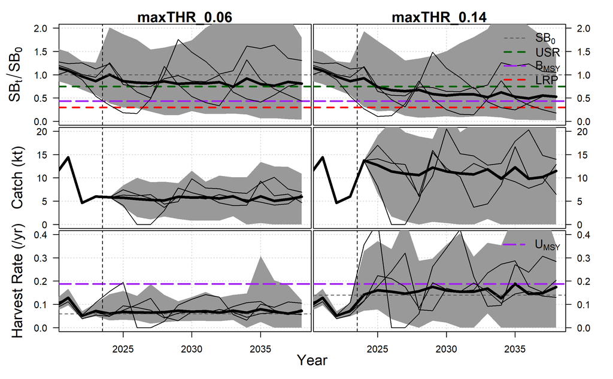

Figure C.1: Simulation envelopes of spawning biomass depletion (top row), catch (middle row) and effective harvest rate (bottom row). Each column shows a single MP, labeled in the top margin. Median values are shown by the thick black lines, the grey shaded region shows the central 95% of each envelope, and three randomly selected individual replicate traces are shown as thin black lines.

# D Exceptional Circumstances

Fishery monitoring data collected since the adoption of the current SOG herring MP does is within expectations. In formal language, there is no indication of exceptional circumstances (Figure D.1), measured by catch and spawn index values within the expected range of previous closed loop simulations.

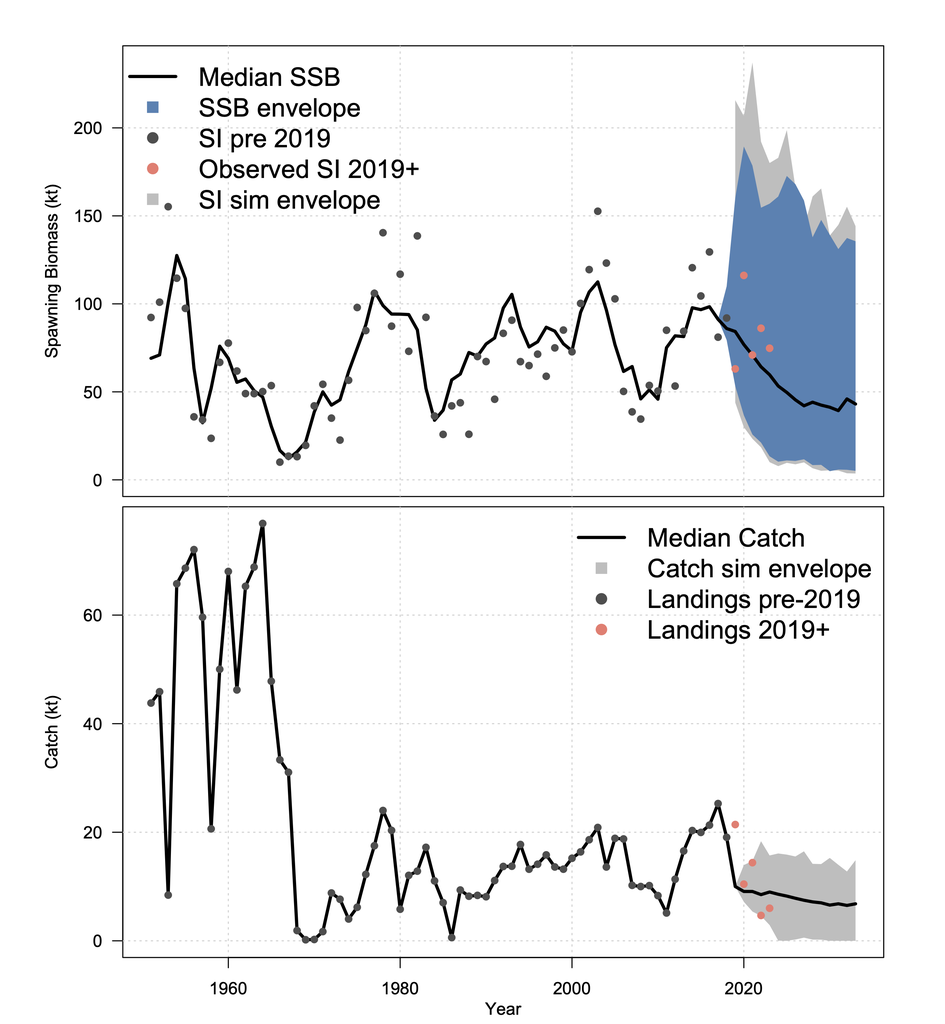

Figure D.1: A graphical test for exceptional circumstances, showing the central 95% of projected spawn index values (top) and catch values (bottom) using the 2019 SOG operating model, with realised data in the history (black points) and projection (red points) overlaid.

Benson, A. J., J. S. Cleary, S. P. Cox, S. Johnson, and M. H. Grinnell. 2022. “[Performance of Management Procedures for British Columbia Pacific Herring (*Clupea Pallasii*) in the Presence of Model Uncertainty: Closing the Gap Between Precautionary Fisheries Theory and Practice](https://www.dfo-mpo.gc.ca/csas-sccs/Publications/ResDocs-DocRech/2022/2022_048-eng.html).” *DFO Can. Sci. Advis. Sec. Res. Doc.* 2022/048: viii + 70p.

Cleary, Jaclyn S., Sarah Hawkshaw, Matthew H. Grinnell, and Chris Grandin. 2019. “[Status of B.C. Pacific Herring (*Clupea Pallasii*) in 2017 and Forecasts for 2018](https://www.dfo-mpo.gc.ca/csas-sccs/Publications/ResDocs-DocRech/2018/2018_028-eng.html).” *DFO Can. Sci. Advis. Sec. Res. Doc.* 2018/028: v + 285p.

DFO. 2020. “[Evaluation of Management Procedures for Pacific Herring (*Clupea Pallasii*) in Haida Gwaii, Prince Rupert District and the Central Coast Management Areas of British Columbia](https://www.dfo-mpo.gc.ca/csas-sccs/Publications/ScR-RS/2020/2020_003-eng.html).” *DFO Can. Sci. Advis. Sec. Sci. Resp.* 2020/003.

———. 2023a. “[Application of a New Modelling Framework for the Assessment of Pacific Herring (*Clupea Pallasii*) Major Stocks and Implementation in the Management Strategy Evaluation Process](https://www.dfo-mpo.gc.ca/csas-sccs/Publications/SAR-AS/2023/2023_040-eng.html).” *DFO Can. Sci. Advis. Sec. Sci. Advis. Rep.* 2023/040.

———. 2023b. “[Management Strategy Evaluation Update and Evaluation of Upper Stock Reference Point Options for Pacific Herring (*Clupea Pallasii*) in British Columbia, Canada](https://www.dfo-mpo.gc.ca/csas-sccs/Publications/ScR-RS/2023/2023_002-eng.html).” *DFO Can. Sci. Advis. Sec. Sci. Resp.* 2023/002.

Kronlund, A. R., R. E. Forrest, J. S. Cleary, and M. H. Grinnell. 2017. “[The Selection and Role of Limit Reference Points for Pacific Herring (*Clupea Pallasii*) in British Columbia, Canada](https://www.dfo-mpo.gc.ca/csas-sccs/Publications/ResDocs-DocRech/2018/2018_009-eng.html).” *DFO Can. Sci. Advis. Sec. Res. Doc.* 2018/009: ix + 125p.

[^1]: Haida Gwaii ’íináang | iinang Pacific Herring: An ecosystem overview and ecosystem-based rebuilding plan. Draft consultation period occurred September 26 to December 16, 2022; Final approval scheduled for fall 2023.